# Risk Factor Analysis

## Outcome Variable

**Outcome Variable:** y_rate_haz

## Predictor Variables

**Intervention Variable:** predfeed3

**Adjustment Set:**

unadjusted

## Stratifying Variables

The analysis was stratified on these variable(s):

- agecat
- studyid
- country

## Data Summary

| agecat | studyid | country | predfeed3 | n_cell | n |
| --- | --- | --- | --- | --- | --- |
| 0-3 months | ki0047075b-MAL-ED | BANGLADESH | 0 | 35 | 239 |
| 0-3 months | ki0047075b-MAL-ED | BANGLADESH | 1 | 204 | 239 |
| 0-3 months | ki0047075b-MAL-ED | BRAZIL | 0 | 80 | 180 |
| 0-3 months | ki0047075b-MAL-ED | BRAZIL | 1 | 100 | 180 |
| 0-3 months | ki0047075b-MAL-ED | INDIA | 0 | 46 | 199 |
| 0-3 months | ki0047075b-MAL-ED | INDIA | 1 | 153 | 199 |
| 0-3 months | ki0047075b-MAL-ED | NEPAL | 0 | 73 | 175 |
| 0-3 months | ki0047075b-MAL-ED | NEPAL | 1 | 102 | 175 |
| 0-3 months | ki0047075b-MAL-ED | PERU | 0 | 89 | 268 |
| 0-3 months | ki0047075b-MAL-ED | PERU | 1 | 179 | 268 |
| 0-3 months | ki0047075b-MAL-ED | SOUTH AFRICA | 0 | 140 | 226 |
| 0-3 months | ki0047075b-MAL-ED | SOUTH AFRICA | 1 | 86 | 226 |
| 0-3 months | ki0047075b-MAL-ED | TANZANIA, UNITED REPUBLIC OF | 0 | 145 | 224 |
| 0-3 months | ki0047075b-MAL-ED | TANZANIA, UNITED REPUBLIC OF | 1 | 79 | 224 |
| 0-3 months | ki1000109-EE | PAKISTAN | 0 | 32 | 592 |
| 0-3 months | ki1000109-EE | PAKISTAN | 1 | 560 | 592 |
| 0-3 months | kiGH5241-JiVitA-3 | BANGLADESH | 0 | 4246 | 39314 |
| 0-3 months | kiGH5241-JiVitA-3 | BANGLADESH | 1 | 35068 | 39314 |
| 0-3 months | kiGH5241-JiVitA-4 | BANGLADESH | 0 | 20 | 242 |
| 0-3 months | kiGH5241-JiVitA-4 | BANGLADESH | 1 | 222 | 242 |
| 3-6 months | ki0047075b-MAL-ED | BANGLADESH | 0 | 33 | 227 |
| 3-6 months | ki0047075b-MAL-ED | BANGLADESH | 1 | 194 | 227 |
| 3-6 months | ki0047075b-MAL-ED | BRAZIL | 0 | 92 | 208 |
| 3-6 months | ki0047075b-MAL-ED | BRAZIL | 1 | 116 | 208 |
| 3-6 months | ki0047075b-MAL-ED | INDIA | 0 | 53 | 229 |
| 3-6 months | ki0047075b-MAL-ED | INDIA | 1 | 176 | 229 |
| 3-6 months | ki0047075b-MAL-ED | NEPAL | 0 | 101 | 232 |
| 3-6 months | ki0047075b-MAL-ED | NEPAL | 1 | 131 | 232 |
| 3-6 months | ki0047075b-MAL-ED | PERU | 0 | 84 | 265 |
| 3-6 months | ki0047075b-MAL-ED | PERU | 1 | 181 | 265 |

[output cut: 54 more lines]

The following strata were considered:

- agecat: 0-3 months, studyid: ki0047075b-MAL-ED, country: BANGLADESH
- agecat: 0-3 months, studyid: ki0047075b-MAL-ED, country: BRAZIL
- agecat: 0-3 months, studyid: ki0047075b-MAL-ED, country: INDIA
- agecat: 0-3 months, studyid: ki0047075b-MAL-ED, country: NEPAL
- agecat: 0-3 months, studyid: ki0047075b-MAL-ED, country: PERU
- agecat: 0-3 months, studyid: ki0047075b-MAL-ED, country: SOUTH AFRICA
- agecat: 0-3 months, studyid: ki0047075b-MAL-ED, country: TANZANIA, UNITED REPUBLIC OF
- agecat: 0-3 months, studyid: ki1000109-EE, country: PAKISTAN
- agecat: 0-3 months, studyid: kiGH5241-JiVitA-3, country: BANGLADESH
- agecat: 0-3 months, studyid: kiGH5241-JiVitA-4, country: BANGLADESH
- agecat: 12-24 months, studyid: ki0047075b-MAL-ED, country: BANGLADESH
- agecat: 12-24 months, studyid: ki0047075b-MAL-ED, country: BRAZIL
- agecat: 12-24 months, studyid: ki0047075b-MAL-ED, country: INDIA
- agecat: 12-24 months, studyid: ki0047075b-MAL-ED, country: NEPAL
- agecat: 12-24 months, studyid: ki0047075b-MAL-ED, country: PERU
- agecat: 12-24 months, studyid: ki0047075b-MAL-ED, country: SOUTH AFRICA
- agecat: 12-24 months, studyid: ki0047075b-MAL-ED, country: TANZANIA, UNITED REPUBLIC OF
- agecat: 12-24 months, studyid: ki1113344-GMS-Nepal, country: NEPAL
- agecat: 12-24 months, studyid: kiGH5241-JiVitA-3, country: BANGLADESH
- agecat: 12-24 months, studyid: kiGH5241-JiVitA-4, country: BANGLADESH
- agecat: 3-6 months, studyid: ki0047075b-MAL-ED, country: BANGLADESH
- agecat: 3-6 months, studyid: ki0047075b-MAL-ED, country: BRAZIL
- agecat: 3-6 months, studyid: ki0047075b-MAL-ED, country: INDIA
- agecat: 3-6 months, studyid: ki0047075b-MAL-ED, country: NEPAL
- agecat: 3-6 months, studyid: ki0047075b-MAL-ED, country: PERU
- agecat: 3-6 months, studyid: ki0047075b-MAL-ED, country: SOUTH AFRICA
- agecat: 3-6 months, studyid: ki0047075b-MAL-ED, country: TANZANIA, UNITED REPUBLIC OF
- agecat: 3-6 months, studyid: ki1000109-EE, country: PAKISTAN
- agecat: 3-6 months, studyid: ki1113344-GMS-Nepal, country: NEPAL
- agecat: 3-6 months, studyid: kiGH5241-JiVitA-3, country: BANGLADESH
- agecat: 3-6 months, studyid: kiGH5241-JiVitA-4, country: BANGLADESH
- agecat: 6-12 months, studyid: ki0047075b-MAL-ED, country: BANGLADESH
- agecat: 6-12 months, studyid: ki0047075b-MAL-ED, country: BRAZIL
- agecat: 6-12 months, studyid: ki0047075b-MAL-ED, country: INDIA
- agecat: 6-12 months, studyid: ki0047075b-MAL-ED, country: NEPAL
- agecat: 6-12 months, studyid: ki0047075b-MAL-ED, country: PERU
- agecat: 6-12 months, studyid: ki0047075b-MAL-ED, country: SOUTH AFRICA
- agecat: 6-12 months, studyid: ki0047075b-MAL-ED, country: TANZANIA, UNITED REPUBLIC OF
- agecat: 6-12 months, studyid: ki1000109-EE, country: PAKISTAN
- agecat: 6-12 months, studyid: ki1113344-GMS-Nepal, country: NEPAL
- agecat: 6-12 months, studyid: kiGH5241-JiVitA-3, country: BANGLADESH
- agecat: 6-12 months, studyid: kiGH5241-JiVitA-4, country: BANGLADESH

### Dropped Strata

Some strata were dropped due to rare outcomes:

- agecat: 3-6 months, studyid: kiGH5241-JiVitA-4, country: BANGLADESH
- agecat: 6-12 months, studyid: ki1000109-EE, country: PAKISTAN
- agecat: 6-12 months, studyid: kiGH5241-JiVitA-4, country: BANGLADESH

## Methods Detail

We’re interested in the causal parameters $E[Y_a]$ for all values of $a \in \mathcal{A}$. These parameters represent the mean outcome if, possibly contrary to fact, we intervened to set all units to have $A=a$. Under the randomization and positivity assumptions, these are identified by the statistical parameters $\psi_a=E_W[E_{Y|A,W}(Y|A=a,W)]$. In addition, we’re interested in the mean of $Y$, $E[Y]$ under no intervention (the observed mean). We will estimate these parameters by using SuperLearner to fit the relevant likelihood factors – $E_{Y|A,W}(Y|A=a,W)$ and $p(A=a|W)$, and then updating our likelihood fit using a joint TMLE.

For unadjusted analyses ($W=\{\}$), initial likelihoods were estimated using Lrnr_glm to estimate the simple $E(Y|A)$ and Lrnr_mean to estimate $p(A)$. For adjusted analyses, a small library containing Lrnr_glmnet, Lrnr_xgboost, and Lrnr_mean was used.

# Results Detail

## Results Plots

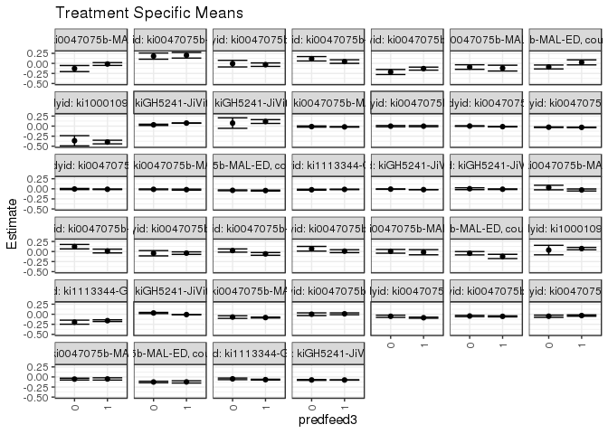

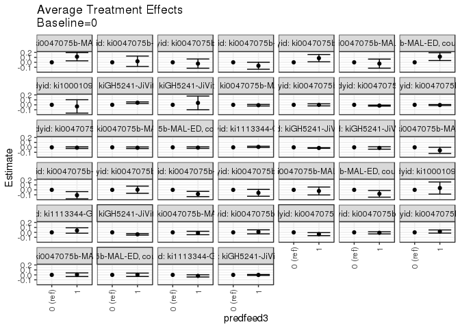

## Results Table

### Parameter: TSM

| agecat | studyid | country | intervention_level | baseline_level | estimate | ci_lower | ci_upper |
| --- | --- | --- | --- | --- | --- | --- | --- |
| 0-3 months | ki0047075b-MAL-ED | BANGLADESH | 0 | NA | -0.1286851 | -0.2042430 | -0.0531271 |
| 0-3 months | ki0047075b-MAL-ED | BANGLADESH | 1 | NA | -0.0154169 | -0.0506753 | 0.0198415 |
| 0-3 months | ki0047075b-MAL-ED | BRAZIL | 0 | NA | 0.1813266 | 0.1042274 | 0.2584258 |
| 0-3 months | ki0047075b-MAL-ED | BRAZIL | 1 | NA | 0.2020843 | 0.1318391 | 0.2723296 |
| 0-3 months | ki0047075b-MAL-ED | INDIA | 0 | NA | -0.0055534 | -0.0880355 | 0.0769287 |
| 0-3 months | ki0047075b-MAL-ED | INDIA | 1 | NA | -0.0315097 | -0.0747431 | 0.0117237 |
| 0-3 months | ki0047075b-MAL-ED | NEPAL | 0 | NA | 0.1149707 | 0.0599257 | 0.1700156 |
| 0-3 months | ki0047075b-MAL-ED | NEPAL | 1 | NA | 0.0457420 | 0.0010491 | 0.0904348 |
| 0-3 months | ki0047075b-MAL-ED | PERU | 0 | NA | -0.2140285 | -0.2764615 | -0.1515955 |
| 0-3 months | ki0047075b-MAL-ED | PERU | 1 | NA | -0.1299529 | -0.1672762 | -0.0926297 |
| 0-3 months | ki0047075b-MAL-ED | SOUTH AFRICA | 0 | NA | -0.0907742 | -0.1472995 | -0.0342489 |
| 0-3 months | ki0047075b-MAL-ED | SOUTH AFRICA | 1 | NA | -0.1173249 | -0.1893075 | -0.0453423 |
| 0-3 months | ki0047075b-MAL-ED | TANZANIA, UNITED REPUBLIC OF | 0 | NA | -0.0888931 | -0.1374515 | -0.0403347 |
| 0-3 months | ki0047075b-MAL-ED | TANZANIA, UNITED REPUBLIC OF | 1 | NA | 0.0254246 | -0.0372530 | 0.0881023 |
| 0-3 months | ki1000109-EE | PAKISTAN | 0 | NA | -0.3641230 | -0.4912529 | -0.2369931 |
| 0-3 months | ki1000109-EE | PAKISTAN | 1 | NA | -0.3962647 | -0.4408433 | -0.3516860 |
| 0-3 months | kiGH5241-JiVitA-3 | BANGLADESH | 0 | NA | 0.0321859 | 0.0167603 | 0.0476115 |
| 0-3 months | kiGH5241-JiVitA-3 | BANGLADESH | 1 | NA | 0.0753668 | 0.0701751 | 0.0805585 |
| 0-3 months | kiGH5241-JiVitA-4 | BANGLADESH | 0 | NA | 0.0755900 | -0.0543405 | 0.2055205 |
| 0-3 months | kiGH5241-JiVitA-4 | BANGLADESH | 1 | NA | 0.1141399 | 0.0668478 | 0.1614319 |
| 3-6 months | ki0047075b-MAL-ED | BANGLADESH | 0 | NA | 0.0317771 | -0.0245894 | 0.0881436 |
| 3-6 months | ki0047075b-MAL-ED | BANGLADESH | 1 | NA | -0.0288560 | -0.0539139 | -0.0037981 |
| 3-6 months | ki0047075b-MAL-ED | BRAZIL | 0 | NA | 0.1207667 | 0.0658330 | 0.1757004 |
| 3-6 months | ki0047075b-MAL-ED | BRAZIL | 1 | NA | 0.0126851 | -0.0344128 | 0.0597830 |
| 3-6 months | ki0047075b-MAL-ED | INDIA | 0 | NA | -0.0421562 | -0.1079365 | 0.0236242 |
| 3-6 months | ki0047075b-MAL-ED | INDIA | 1 | NA | -0.0395135 | -0.0707103 | -0.0083167 |
| 3-6 months | ki0047075b-MAL-ED | NEPAL | 0 | NA | 0.0246485 | -0.0159998 | 0.0652969 |
| 3-6 months | ki0047075b-MAL-ED | NEPAL | 1 | NA | -0.0588789 | -0.0928150 | -0.0249429 |
| 3-6 months | ki0047075b-MAL-ED | PERU | 0 | NA | 0.0691082 | 0.0109995 | 0.1272168 |
| 3-6 months | ki0047075b-MAL-ED | PERU | 1 | NA | 0.0094004 | -0.0271766 | 0.0459773 |
| 3-6 months | ki0047075b-MAL-ED | SOUTH AFRICA | 0 | NA | 0.0059063 | -0.0417337 | 0.0535464 |
| 3-6 months | ki0047075b-MAL-ED | SOUTH AFRICA | 1 | NA | -0.0170997 | -0.0809397 | 0.0467403 |
| 3-6 months | ki0047075b-MAL-ED | TANZANIA, UNITED REPUBLIC OF | 0 | NA | -0.0423123 | -0.0835275 | -0.0010971 |
| 3-6 months | ki0047075b-MAL-ED | TANZANIA, UNITED REPUBLIC OF | 1 | NA | -0.1221026 | -0.1750547 | -0.0691505 |
| 3-6 months | ki1000109-EE | PAKISTAN | 0 | NA | 0.0365247 | -0.0820478 | 0.1550972 |
| 3-6 months | ki1000109-EE | PAKISTAN | 1 | NA | 0.0733013 | 0.0442604 | 0.1023422 |
| 3-6 months | ki1113344-GMS-Nepal | NEPAL | 0 | NA | -0.1972621 | -0.2471509 | -0.1473733 |
| 3-6 months | ki1113344-GMS-Nepal | NEPAL | 1 | NA | -0.1596135 | -0.1808049 | -0.1384221 |
| 3-6 months | kiGH5241-JiVitA-3 | BANGLADESH | 0 | NA | 0.0316666 | 0.0168549 | 0.0464782 |
| 3-6 months | kiGH5241-JiVitA-3 | BANGLADESH | 1 | NA | -0.0080594 | -0.0131027 | -0.0030162 |
| 6-12 months | ki0047075b-MAL-ED | BANGLADESH | 0 | NA | -0.0697800 | -0.1022409 | -0.0373191 |
| 6-12 months | ki0047075b-MAL-ED | BANGLADESH | 1 | NA | -0.0825731 | -0.0935679 | -0.0715783 |
| 6-12 months | ki0047075b-MAL-ED | BRAZIL | 0 | NA | 0.0007871 | -0.0323705 | 0.0339447 |
| 6-12 months | ki0047075b-MAL-ED | BRAZIL | 1 | NA | 0.0109762 | -0.0122175 | 0.0341699 |
| 6-12 months | ki0047075b-MAL-ED | INDIA | 0 | NA | -0.0505955 | -0.0780565 | -0.0231345 |
| 6-12 months | ki0047075b-MAL-ED | INDIA | 1 | NA | -0.0862456 | -0.0995781 | -0.0729131 |
| 6-12 months | ki0047075b-MAL-ED | NEPAL | 0 | NA | -0.0436185 | -0.0604650 | -0.0267720 |
| 6-12 months | ki0047075b-MAL-ED | NEPAL | 1 | NA | -0.0524533 | -0.0660664 | -0.0388402 |
| 6-12 months | ki0047075b-MAL-ED | PERU | 0 | NA | -0.0490862 | -0.0760719 | -0.0221006 |
| 6-12 months | ki0047075b-MAL-ED | PERU | 1 | NA | -0.0323000 | -0.0487202 | -0.0158797 |
| 6-12 months | ki0047075b-MAL-ED | SOUTH AFRICA | 0 | NA | -0.0530111 | -0.0755328 | -0.0304895 |
| 6-12 months | ki0047075b-MAL-ED | SOUTH AFRICA | 1 | NA | -0.0494904 | -0.0778123 | -0.0211685 |
| 6-12 months | ki0047075b-MAL-ED | TANZANIA, UNITED REPUBLIC OF | 0 | NA | -0.1254996 | -0.1448943 | -0.1061048 |
| 6-12 months | ki0047075b-MAL-ED | TANZANIA, UNITED REPUBLIC OF | 1 | NA | -0.1232092 | -0.1509700 | -0.0954485 |
| 6-12 months | ki1113344-GMS-Nepal | NEPAL | 0 | NA | -0.0468419 | -0.0667108 | -0.0269731 |
| 6-12 months | ki1113344-GMS-Nepal | NEPAL | 1 | NA | -0.0672177 | -0.0775306 | -0.0569049 |
| 6-12 months | kiGH5241-JiVitA-3 | BANGLADESH | 0 | NA | -0.0743765 | -0.0837046 | -0.0650484 |
| 6-12 months | kiGH5241-JiVitA-3 | BANGLADESH | 1 | NA | -0.0754246 | -0.0783850 | -0.0724641 |
| 12-24 months | ki0047075b-MAL-ED | BANGLADESH | 0 | NA | -0.0117482 | -0.0264745 | 0.0029781 |
| 12-24 months | ki0047075b-MAL-ED | BANGLADESH | 1 | NA | -0.0192118 | -0.0250957 | -0.0133279 |
| 12-24 months | ki0047075b-MAL-ED | BRAZIL | 0 | NA | -0.0010151 | -0.0166119 | 0.0145818 |
| 12-24 months | ki0047075b-MAL-ED | BRAZIL | 1 | NA | -0.0015075 | -0.0158807 | 0.0128657 |
| 12-24 months | ki0047075b-MAL-ED | INDIA | 0 | NA | 0.0018646 | -0.0064817 | 0.0102109 |
| 12-24 months | ki0047075b-MAL-ED | INDIA | 1 | NA | -0.0134705 | -0.0196066 | -0.0073344 |
| 12-24 months | ki0047075b-MAL-ED | NEPAL | 0 | NA | -0.0271434 | -0.0345791 | -0.0197077 |
| 12-24 months | ki0047075b-MAL-ED | NEPAL | 1 | NA | -0.0313558 | -0.0382503 | -0.0244613 |
| 12-24 months | ki0047075b-MAL-ED | PERU | 0 | NA | -0.0045506 | -0.0184765 | 0.0093753 |
| 12-24 months | ki0047075b-MAL-ED | PERU | 1 | NA | -0.0110220 | -0.0190506 | -0.0029933 |
| 12-24 months | ki0047075b-MAL-ED | SOUTH AFRICA | 0 | NA | -0.0125416 | -0.0220694 | -0.0030138 |
| 12-24 months | ki0047075b-MAL-ED | SOUTH AFRICA | 1 | NA | -0.0205203 | -0.0332221 | -0.0078185 |
| 12-24 months | ki0047075b-MAL-ED | TANZANIA, UNITED REPUBLIC OF | 0 | NA | -0.0374632 | -0.0479355 | -0.0269909 |
| 12-24 months | ki0047075b-MAL-ED | TANZANIA, UNITED REPUBLIC OF | 1 | NA | -0.0431071 | -0.0550526 | -0.0311617 |
| 12-24 months | ki1113344-GMS-Nepal | NEPAL | 0 | NA | -0.0231563 | -0.0349063 | -0.0114062 |
| 12-24 months | ki1113344-GMS-Nepal | NEPAL | 1 | NA | -0.0144328 | -0.0205876 | -0.0082781 |
| 12-24 months | kiGH5241-JiVitA-3 | BANGLADESH | 0 | NA | -0.0075082 | -0.0135930 | -0.0014234 |
| 12-24 months | kiGH5241-JiVitA-3 | BANGLADESH | 1 | NA | -0.0202539 | -0.0222016 | -0.0183062 |
| 12-24 months | kiGH5241-JiVitA-4 | BANGLADESH | 0 | NA | 0.0024601 | -0.0203642 | 0.0252845 |
| 12-24 months | kiGH5241-JiVitA-4 | BANGLADESH | 1 | NA | -0.0099089 | -0.0183914 | -0.0014264 |

### Parameter: E(Y)

| agecat | studyid | country | intervention_level | baseline_level | estimate | ci_lower | ci_upper |
| --- | --- | --- | --- | --- | --- | --- | --- |
| 0-3 months | ki0047075b-MAL-ED | BANGLADESH | NA | NA | -0.0320043 | -0.0644701 | 0.0004615 |
| 0-3 months | ki0047075b-MAL-ED | BRAZIL | NA | NA | 0.1928587 | 0.1409027 | 0.2448147 |
| 0-3 months | ki0047075b-MAL-ED | INDIA | NA | NA | -0.0255097 | -0.0638598 | 0.0128403 |
| 0-3 months | ki0047075b-MAL-ED | NEPAL | NA | NA | 0.0746202 | 0.0395269 | 0.1097135 |
| 0-3 months | ki0047075b-MAL-ED | PERU | NA | NA | -0.1578735 | -0.1906434 | -0.1251037 |
| 0-3 months | ki0047075b-MAL-ED | SOUTH AFRICA | NA | NA | -0.1008775 | -0.1453661 | -0.0563889 |
| 0-3 months | ki0047075b-MAL-ED | TANZANIA, UNITED REPUBLIC OF | NA | NA | -0.0485757 | -0.0876660 | -0.0094853 |
| 0-3 months | ki1000109-EE | PAKISTAN | NA | NA | -0.3945273 | -0.4372606 | -0.3517940 |
| 0-3 months | kiGH5241-JiVitA-3 | BANGLADESH | NA | NA | 0.0707032 | 0.0657297 | 0.0756767 |
| 0-3 months | kiGH5241-JiVitA-4 | BANGLADESH | NA | NA | 0.1109539 | 0.0661941 | 0.1557138 |
| 3-6 months | ki0047075b-MAL-ED | BANGLADESH | NA | NA | -0.0200415 | -0.0431395 | 0.0030565 |
| 3-6 months | ki0047075b-MAL-ED | BRAZIL | NA | NA | 0.0604904 | 0.0239698 | 0.0970111 |
| 3-6 months | ki0047075b-MAL-ED | INDIA | NA | NA | -0.0401251 | -0.0685271 | -0.0117231 |
| 3-6 months | ki0047075b-MAL-ED | NEPAL | NA | NA | -0.0225157 | -0.0491401 | 0.0041087 |
| 3-6 months | ki0047075b-MAL-ED | PERU | NA | NA | 0.0283266 | -0.0028926 | 0.0595459 |
| 3-6 months | ki0047075b-MAL-ED | SOUTH AFRICA | NA | NA | -0.0024150 | -0.0406234 | 0.0357934 |
| 3-6 months | ki0047075b-MAL-ED | TANZANIA, UNITED REPUBLIC OF | NA | NA | -0.0727901 | -0.1056963 | -0.0398840 |
| 3-6 months | ki1000109-EE | PAKISTAN | NA | NA | 0.0708495 | 0.0425982 | 0.0991009 |
| 3-6 months | ki1113344-GMS-Nepal | NEPAL | NA | NA | -0.1660455 | -0.1856196 | -0.1464714 |
| 3-6 months | kiGH5241-JiVitA-3 | BANGLADESH | NA | NA | -0.0042530 | -0.0091354 | 0.0006295 |
| 6-12 months | ki0047075b-MAL-ED | BANGLADESH | NA | NA | -0.0807371 | -0.0912604 | -0.0702138 |
| 6-12 months | ki0047075b-MAL-ED | BRAZIL | NA | NA | 0.0065644 | -0.0129183 | 0.0260472 |
| 6-12 months | ki0047075b-MAL-ED | INDIA | NA | NA | -0.0777727 | -0.0900154 | -0.0655300 |
| 6-12 months | ki0047075b-MAL-ED | NEPAL | NA | NA | -0.0486002 | -0.0592412 | -0.0379593 |
| 6-12 months | ki0047075b-MAL-ED | PERU | NA | NA | -0.0374212 | -0.0515266 | -0.0233158 |
| 6-12 months | ki0047075b-MAL-ED | SOUTH AFRICA | NA | NA | -0.0517337 | -0.0693851 | -0.0340823 |
| 6-12 months | ki0047075b-MAL-ED | TANZANIA, UNITED REPUBLIC OF | NA | NA | -0.1246447 | -0.1406180 | -0.1086713 |
| 6-12 months | ki1113344-GMS-Nepal | NEPAL | NA | NA | -0.0638477 | -0.0730913 | -0.0546041 |
| 6-12 months | kiGH5241-JiVitA-3 | BANGLADESH | NA | NA | -0.0753247 | -0.0782379 | -0.0724114 |
| 12-24 months | ki0047075b-MAL-ED | BANGLADESH | NA | NA | -0.0181403 | -0.0236170 | -0.0126636 |
| 12-24 months | ki0047075b-MAL-ED | BRAZIL | NA | NA | -0.0013016 | -0.0119070 | 0.0093038 |
| 12-24 months | ki0047075b-MAL-ED | INDIA | NA | NA | -0.0097570 | -0.0149006 | -0.0046135 |
| 12-24 months | ki0047075b-MAL-ED | NEPAL | NA | NA | -0.0295235 | -0.0345942 | -0.0244528 |
| 12-24 months | ki0047075b-MAL-ED | PERU | NA | NA | -0.0090124 | -0.0160498 | -0.0019751 |
| 12-24 months | ki0047075b-MAL-ED | SOUTH AFRICA | NA | NA | -0.0153199 | -0.0229604 | -0.0076795 |
| 12-24 months | ki0047075b-MAL-ED | TANZANIA, UNITED REPUBLIC OF | NA | NA | -0.0396040 | -0.0475364 | -0.0316716 |
| 12-24 months | ki1113344-GMS-Nepal | NEPAL | NA | NA | -0.0158588 | -0.0213657 | -0.0103518 |
| 12-24 months | kiGH5241-JiVitA-3 | BANGLADESH | NA | NA | -0.0189244 | -0.0207907 | -0.0170581 |
| 12-24 months | kiGH5241-JiVitA-4 | BANGLADESH | NA | NA | -0.0089754 | -0.0170317 | -0.0009191 |

### Parameter: ATE

| agecat | studyid | country | intervention_level | baseline_level | estimate | ci_lower | ci_upper |
| --- | --- | --- | --- | --- | --- | --- | --- |
| 0-3 months | ki0047075b-MAL-ED | BANGLADESH | 0 | 0 | 0.0000000 | 0.0000000 | 0.0000000 |
| 0-3 months | ki0047075b-MAL-ED | BANGLADESH | 1 | 0 | 0.1132682 | 0.0298886 | 0.1966478 |
| 0-3 months | ki0047075b-MAL-ED | BRAZIL | 0 | 0 | 0.0000000 | 0.0000000 | 0.0000000 |
| 0-3 months | ki0047075b-MAL-ED | BRAZIL | 1 | 0 | 0.0207578 | -0.0835432 | 0.1250587 |
| 0-3 months | ki0047075b-MAL-ED | INDIA | 0 | 0 | 0.0000000 | 0.0000000 | 0.0000000 |
| 0-3 months | ki0047075b-MAL-ED | INDIA | 1 | 0 | -0.0259563 | -0.1190822 | 0.0671695 |
| 0-3 months | ki0047075b-MAL-ED | NEPAL | 0 | 0 | 0.0000000 | 0.0000000 | 0.0000000 |
| 0-3 months | ki0047075b-MAL-ED | NEPAL | 1 | 0 | -0.0692287 | -0.1401329 | 0.0016754 |
| 0-3 months | ki0047075b-MAL-ED | PERU | 0 | 0 | 0.0000000 | 0.0000000 | 0.0000000 |
| 0-3 months | ki0047075b-MAL-ED | PERU | 1 | 0 | 0.0840756 | 0.0113369 | 0.1568142 |
| 0-3 months | ki0047075b-MAL-ED | SOUTH AFRICA | 0 | 0 | 0.0000000 | 0.0000000 | 0.0000000 |
| 0-3 months | ki0047075b-MAL-ED | SOUTH AFRICA | 1 | 0 | -0.0265507 | -0.1180745 | 0.0649730 |
| 0-3 months | ki0047075b-MAL-ED | TANZANIA, UNITED REPUBLIC OF | 0 | 0 | 0.0000000 | 0.0000000 | 0.0000000 |
| 0-3 months | ki0047075b-MAL-ED | TANZANIA, UNITED REPUBLIC OF | 1 | 0 | 0.1143177 | 0.0350309 | 0.1936045 |
| 0-3 months | ki1000109-EE | PAKISTAN | 0 | 0 | 0.0000000 | 0.0000000 | 0.0000000 |
| 0-3 months | ki1000109-EE | PAKISTAN | 1 | 0 | -0.0321417 | -0.1668609 | 0.1025776 |
| 0-3 months | kiGH5241-JiVitA-3 | BANGLADESH | 0 | 0 | 0.0000000 | 0.0000000 | 0.0000000 |
| 0-3 months | kiGH5241-JiVitA-3 | BANGLADESH | 1 | 0 | 0.0431809 | 0.0270895 | 0.0592723 |
| 0-3 months | kiGH5241-JiVitA-4 | BANGLADESH | 0 | 0 | 0.0000000 | 0.0000000 | 0.0000000 |
| 0-3 months | kiGH5241-JiVitA-4 | BANGLADESH | 1 | 0 | 0.0385499 | -0.0992736 | 0.1763734 |
| 3-6 months | ki0047075b-MAL-ED | BANGLADESH | 0 | 0 | 0.0000000 | 0.0000000 | 0.0000000 |
| 3-6 months | ki0047075b-MAL-ED | BANGLADESH | 1 | 0 | -0.0606331 | -0.1223185 | 0.0010523 |
| 3-6 months | ki0047075b-MAL-ED | BRAZIL | 0 | 0 | 0.0000000 | 0.0000000 | 0.0000000 |
| 3-6 months | ki0047075b-MAL-ED | BRAZIL | 1 | 0 | -0.1080816 | -0.1804413 | -0.0357219 |
| 3-6 months | ki0047075b-MAL-ED | INDIA | 0 | 0 | 0.0000000 | 0.0000000 | 0.0000000 |
| 3-6 months | ki0047075b-MAL-ED | INDIA | 1 | 0 | 0.0026427 | -0.0701604 | 0.0754458 |
| 3-6 months | ki0047075b-MAL-ED | NEPAL | 0 | 0 | 0.0000000 | 0.0000000 | 0.0000000 |
| 3-6 months | ki0047075b-MAL-ED | NEPAL | 1 | 0 | -0.0835275 | -0.1364797 | -0.0305752 |
| 3-6 months | ki0047075b-MAL-ED | PERU | 0 | 0 | 0.0000000 | 0.0000000 | 0.0000000 |
| 3-6 months | ki0047075b-MAL-ED | PERU | 1 | 0 | -0.0597078 | -0.1283699 | 0.0089544 |
| 3-6 months | ki0047075b-MAL-ED | SOUTH AFRICA | 0 | 0 | 0.0000000 | 0.0000000 | 0.0000000 |
| 3-6 months | ki0047075b-MAL-ED | SOUTH AFRICA | 1 | 0 | -0.0230060 | -0.1026623 | 0.0566502 |
| 3-6 months | ki0047075b-MAL-ED | TANZANIA, UNITED REPUBLIC OF | 0 | 0 | 0.0000000 | 0.0000000 | 0.0000000 |
| 3-6 months | ki0047075b-MAL-ED | TANZANIA, UNITED REPUBLIC OF | 1 | 0 | -0.0797903 | -0.1468918 | -0.0126888 |
| 3-6 months | ki1000109-EE | PAKISTAN | 0 | 0 | 0.0000000 | 0.0000000 | 0.0000000 |
| 3-6 months | ki1000109-EE | PAKISTAN | 1 | 0 | 0.0367766 | -0.0853004 | 0.1588537 |
| 3-6 months | ki1113344-GMS-Nepal | NEPAL | 0 | 0 | 0.0000000 | 0.0000000 | 0.0000000 |
| 3-6 months | ki1113344-GMS-Nepal | NEPAL | 1 | 0 | 0.0376486 | -0.0165545 | 0.0918516 |
| 3-6 months | kiGH5241-JiVitA-3 | BANGLADESH | 0 | 0 | 0.0000000 | 0.0000000 | 0.0000000 |
| 3-6 months | kiGH5241-JiVitA-3 | BANGLADESH | 1 | 0 | -0.0397260 | -0.0550224 | -0.0244296 |
| 6-12 months | ki0047075b-MAL-ED | BANGLADESH | 0 | 0 | 0.0000000 | 0.0000000 | 0.0000000 |
| 6-12 months | ki0047075b-MAL-ED | BANGLADESH | 1 | 0 | -0.0127931 | -0.0470655 | 0.0214793 |
| 6-12 months | ki0047075b-MAL-ED | BRAZIL | 0 | 0 | 0.0000000 | 0.0000000 | 0.0000000 |
| 6-12 months | ki0047075b-MAL-ED | BRAZIL | 1 | 0 | 0.0101891 | -0.0302753 | 0.0506536 |
| 6-12 months | ki0047075b-MAL-ED | INDIA | 0 | 0 | 0.0000000 | 0.0000000 | 0.0000000 |
| 6-12 months | ki0047075b-MAL-ED | INDIA | 1 | 0 | -0.0356501 | -0.0661765 | -0.0051236 |
| 6-12 months | ki0047075b-MAL-ED | NEPAL | 0 | 0 | 0.0000000 | 0.0000000 | 0.0000000 |
| 6-12 months | ki0047075b-MAL-ED | NEPAL | 1 | 0 | -0.0088348 | -0.0304941 | 0.0128244 |
| 6-12 months | ki0047075b-MAL-ED | PERU | 0 | 0 | 0.0000000 | 0.0000000 | 0.0000000 |
| 6-12 months | ki0047075b-MAL-ED | PERU | 1 | 0 | 0.0167863 | -0.0148025 | 0.0483751 |
| 6-12 months | ki0047075b-MAL-ED | SOUTH AFRICA | 0 | 0 | 0.0000000 | 0.0000000 | 0.0000000 |
| 6-12 months | ki0047075b-MAL-ED | SOUTH AFRICA | 1 | 0 | 0.0035207 | -0.0326643 | 0.0397057 |
| 6-12 months | ki0047075b-MAL-ED | TANZANIA, UNITED REPUBLIC OF | 0 | 0 | 0.0000000 | 0.0000000 | 0.0000000 |
| 6-12 months | ki0047075b-MAL-ED | TANZANIA, UNITED REPUBLIC OF | 1 | 0 | 0.0022903 | -0.0315743 | 0.0361550 |
| 6-12 months | ki1113344-GMS-Nepal | NEPAL | 0 | 0 | 0.0000000 | 0.0000000 | 0.0000000 |
| 6-12 months | ki1113344-GMS-Nepal | NEPAL | 1 | 0 | -0.0203758 | -0.0427616 | 0.0020101 |
| 6-12 months | kiGH5241-JiVitA-3 | BANGLADESH | 0 | 0 | 0.0000000 | 0.0000000 | 0.0000000 |
| 6-12 months | kiGH5241-JiVitA-3 | BANGLADESH | 1 | 0 | -0.0010481 | -0.0105227 | 0.0084266 |
| 12-24 months | ki0047075b-MAL-ED | BANGLADESH | 0 | 0 | 0.0000000 | 0.0000000 | 0.0000000 |
| 12-24 months | ki0047075b-MAL-ED | BANGLADESH | 1 | 0 | -0.0074636 | -0.0233219 | 0.0083947 |
| 12-24 months | ki0047075b-MAL-ED | BRAZIL | 0 | 0 | 0.0000000 | 0.0000000 | 0.0000000 |
| 12-24 months | ki0047075b-MAL-ED | BRAZIL | 1 | 0 | -0.0004924 | -0.0217021 | 0.0207172 |
| 12-24 months | ki0047075b-MAL-ED | INDIA | 0 | 0 | 0.0000000 | 0.0000000 | 0.0000000 |
| 12-24 months | ki0047075b-MAL-ED | INDIA | 1 | 0 | -0.0153351 | -0.0256942 | -0.0049759 |
| 12-24 months | ki0047075b-MAL-ED | NEPAL | 0 | 0 | 0.0000000 | 0.0000000 | 0.0000000 |
| 12-24 months | ki0047075b-MAL-ED | NEPAL | 1 | 0 | -0.0042124 | -0.0143526 | 0.0059278 |
| 12-24 months | ki0047075b-MAL-ED | PERU | 0 | 0 | 0.0000000 | 0.0000000 | 0.0000000 |
| 12-24 months | ki0047075b-MAL-ED | PERU | 1 | 0 | -0.0064714 | -0.0225459 | 0.0096031 |
| 12-24 months | ki0047075b-MAL-ED | SOUTH AFRICA | 0 | 0 | 0.0000000 | 0.0000000 | 0.0000000 |
| 12-24 months | ki0047075b-MAL-ED | SOUTH AFRICA | 1 | 0 | -0.0079787 | -0.0238568 | 0.0078995 |
| 12-24 months | ki0047075b-MAL-ED | TANZANIA, UNITED REPUBLIC OF | 0 | 0 | 0.0000000 | 0.0000000 | 0.0000000 |
| 12-24 months | ki0047075b-MAL-ED | TANZANIA, UNITED REPUBLIC OF | 1 | 0 | -0.0056440 | -0.0215299 | 0.0102420 |
| 12-24 months | ki1113344-GMS-Nepal | NEPAL | 0 | 0 | 0.0000000 | 0.0000000 | 0.0000000 |
| 12-24 months | ki1113344-GMS-Nepal | NEPAL | 1 | 0 | 0.0087234 | -0.0045410 | 0.0219879 |
| 12-24 months | kiGH5241-JiVitA-3 | BANGLADESH | 0 | 0 | 0.0000000 | 0.0000000 | 0.0000000 |
| 12-24 months | kiGH5241-JiVitA-3 | BANGLADESH | 1 | 0 | -0.0127457 | -0.0191180 | -0.0063735 |
| 12-24 months | kiGH5241-JiVitA-4 | BANGLADESH | 0 | 0 | 0.0000000 | 0.0000000 | 0.0000000 |
| 12-24 months | kiGH5241-JiVitA-4 | BANGLADESH | 1 | 0 | -0.0123690 | -0.0366730 | 0.0119350 |